# Gradescocpe: Sample Assignment

Gov 50

**Instructor Note**: This is an example problem set submission for Gradescope. For a problem set, you could describe the topic here. Since answers are hidden below when knitted (`echo=FALSE`), instructors can knit this file to HTML in RMarkdown and distribute that to students as an assignment.

## Question 1

The `tidyverse` package gives us access to the `us_rent_income` dataset. This question asks students to manipulate that object and save it to an object named `q1`.

Perform the following steps on `us_rent_income` to create a new `tibble` named `q1`:

1. Filter to only states with values of `estimate` above 20000.
2. Then, select only the `GEOID`, `NAME`, and `estimate` columns.

**Final Answer**: a tibble called `q1` with 51 rows and 3 columns as specified above.

**Instructor Note**: Instructors could also ask students to read a provided dataset with a function like `read_csv()`. If the autograder needs to access a file, you can include it in the `autograder` folder uploaded to Gradescope. We specify these requirements above to let them know what Gradescope is looking for.

## Question 2

**Instructor Note**: If a question will not be autograded, Gradescope will simply skip it. However, make sure any packages you ask the students to use are still installed in `setup.sh`. This is why we preemptively installed `ggthemes` in `setup.sh`, just to be safe.

For example, this question may require students to make some sort of plot.

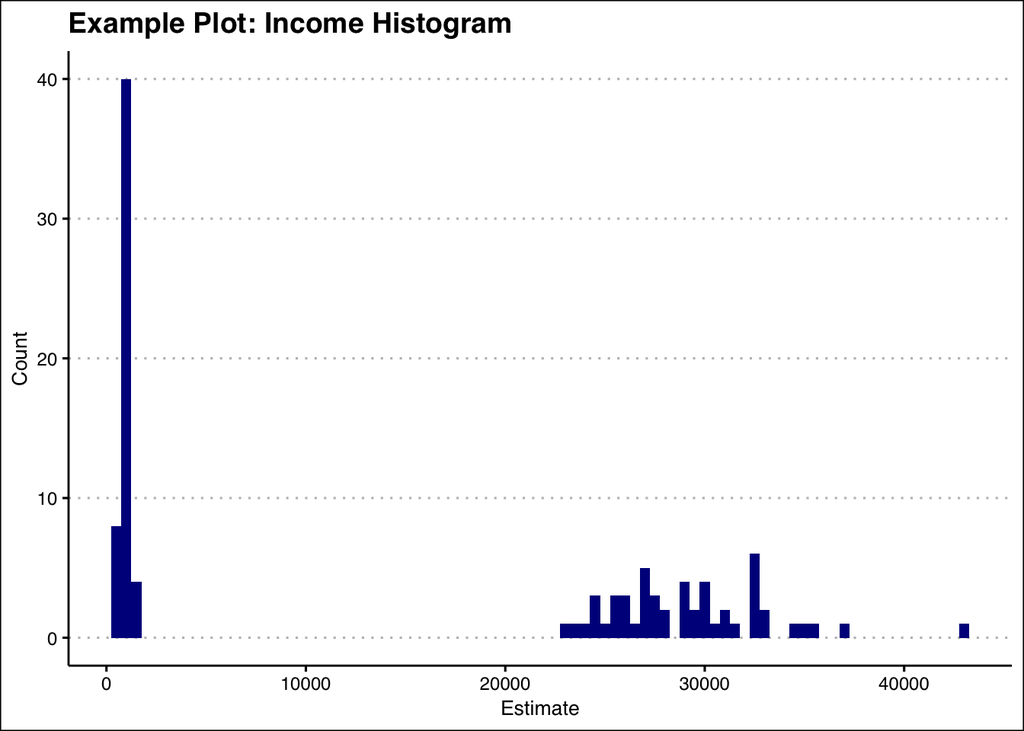